# Market Target analysis

The Geek Squad

2022-08-04

# 1 **Market Target Analysis**

### 1.0.1 **Introduction**

Term deposits are a major source of income for a bank. A term deposit is a cash investment held at a financial institution. Your money is invested for an agreed rate of interest over a fixed amount of time, or term. The bank has various outreach plans to sell term deposits to their customers such as email marketing, advertisements, telephonic marketing, and digital marketing.

### 1.0.2 **Problem Statement**

Telephonic marketing campaigns still remain one of the most effective way to reach out to people. However, they require huge investment as large call centers are hired to actually execute these campaigns. Hence, it is crucial to identify the customers most likely to convert beforehand so that they can be specifically targeted via call. The data is related to direct marketing campaigns (phone calls) of a Portuguese banking institution.

### 1.0.3 **Objectives**

#### 1.0.3.1 **Main Objective**

To build a model that predicts if the client will subscribe to a term deposit or not

#### 1.0.3.2 **Specific Objective**

1. To determine how the given features are affect Subscription to a term deposit

### 1.0.4 **Metrics Of success**

1. To Answer questions derived from our specific objective.
2. Find and deal with outliers, anomalies, and missing data within the data set.
3. Perform EDA.
4. Building a model to predict if a client will subscribe to a term deposit or not ( best model should have a Balanced Accuracy score above 80)
5. From our insights provide a conclusion and recommendation.

# 2 **Data Understanding**

Loading Important Libraries

```r
library(data.table)
library(dplyr)
library(tidyverse)
library(ggplot2)
```

We have two sets of data set i.e train and test , will load them separately as follows:

**a. Loading the train data set**

```r
library(readr)
train <- read_delim("train.csv", delim = ";",
    escape_double = FALSE, trim_ws = TRUE)
```

Previewing first six rows

```r
head(train)
```

| age | job | marital | education | default | balance | housing | loan | contact | day | month | duration | campaign | pdays | previous | poutcome | y |
| --- | --- | --- | --- | --- | --- | --- | --- | --- | --- | --- | --- | --- | --- | --- | --- | --- |
| 58 | management | married | tertiary | no | 2143 | yes | no | unknown | 5 | may | 261 | 1 | -1 | 0 | unknown | no |
| 44 | technician | single | secondary | no | 29 | yes | no | unknown | 5 | may | 151 | 1 | -1 | 0 | unknown | no |
| 33 | entrepreneur | married | secondary | no | 2 | yes | yes | unknown | 5 | may | 76 | 1 | -1 | 0 | unknown | no |
| 47 | blue-collar | married | unknown | no | 1506 | yes | no | unknown | 5 | may | 92 | 1 | -1 | 0 | unknown | no |
| 33 | unknown | single | unknown | no | 1 | no | no | unknown | 5 | may | 198 | 1 | -1 | 0 | unknown | no |
| 35 | management | married | tertiary | no | 231 | yes | no | unknown | 5 | may | 139 | 1 | -1 | 0 | unknown | no |

Checking number of rows and columns

```r
dim(train)
```

```
## [1] 45211    17
```

We have 45211 rows and 17 columns

Checking the data types

```r
str(train)
```

```
## spec_tbl_df [45,211 × 17] (S3: spec_tbl_df/tbl_df/tbl/data.frame)
##  $ age      : num [1:45211] 58 44 33 47 33 35 28 42 58 43 ...
##  $ job      : chr [1:45211] "management" "technician" "entrepreneur" "blue-collar" ...
##  $ marital  : chr [1:45211] "married" "single" "married" "married" ...
##  $ education: chr [1:45211] "tertiary" "secondary" "secondary" "unknown" ...
##  $ default  : chr [1:45211] "no" "no" "no" "no" ...
##  $ balance  : num [1:45211] 2143 29 2 1506 1 ...
##  $ housing  : chr [1:45211] "yes" "yes" "yes" "yes" ...
##  $ loan     : chr [1:45211] "no" "no" "yes" "no" ...
##  $ contact  : chr [1:45211] "unknown" "unknown" "unknown" "unknown" ...
##  $ day      : num [1:45211] 5 5 5 5 5 5 5 5 5 5 ...
##  $ month    : chr [1:45211] "may" "may" "may" "may" ...
##  $ duration : num [1:45211] 261 151 76 92 198 139 217 380 50 55 ...
##  $ campaign : num [1:45211] 1 1 1 1 1 1 1 1 1 1 ...
##  $ pdays    : num [1:45211] -1 -1 -1 -1 -1 -1 -1 -1 -1 -1 ...
##  $ previous : num [1:45211] 0 0 0 0 0 0 0 0 0 0 ...
##  $ poutcome : chr [1:45211] "unknown" "unknown" "unknown" "unknown" ...
##  $ y        : chr [1:45211] "no" "no" "no" "no" ...
##  - attr(*, "spec")=
##   .. cols(
##   ..   age = col_double(),
##   ..   job = col_character(),
##   ..   marital = col_character(),
##   ..   education = col_character(),
##   ..   default = col_character(),
##   ..   balance = col_double(),
##   ..   housing = col_character(),
##   ..   loan = col_character(),
##   ..   contact = col_character(),
##   ..   day = col_double(),
##   ..   month = col_character(),
##   ..   duration = col_double(),
##   ..   campaign = col_double(),
##   ..   pdays = col_double(),
##   ..   previous = col_double(),
##   ..   poutcome = col_character(),
##   ..   y = col_character()
##   .. )
##  - attr(*, "problems")=<externalptr>
```

We have a mixture of numeric, and categorical variables

**b. Loading the test data set**

```r
library(readr)
test <- read_delim("test.csv", delim = ";",
    escape_double = FALSE, trim_ws = TRUE)
```

Previewing the first six rows

```r
head(test)
```

| age | job | marital | education | default | balance | housing | loan | contact | day | month | duration | campaign | pdays | previous | poutcome | y |
| --- | --- | --- | --- | --- | --- | --- | --- | --- | --- | --- | --- | --- | --- | --- | --- | --- |
| 30 | unemployed | married | primary | no | 1787 | no | no | cellular | 19 | oct | 79 | 1 | -1 | 0 | unknown | no |
| 33 | services | married | secondary | no | 4789 | yes | yes | cellular | 11 | may | 220 | 1 | 339 | 4 | failure | no |
| 35 | management | single | tertiary | no | 1350 | yes | no | cellular | 16 | apr | 185 | 1 | 330 | 1 | failure | no |
| 30 | management | married | tertiary | no | 1476 | yes | yes | unknown | 3 | jun | 199 | 4 | -1 | 0 | unknown | no |
| 59 | blue-collar | married | secondary | no | 0 | yes | no | unknown | 5 | may | 226 | 1 | -1 | 0 | unknown | no |
| 35 | management | single | tertiary | no | 747 | no | no | cellular | 23 | feb | 141 | 2 | 176 | 3 | failure | no |

Checking the number of rows and columns

```r
dim(test)
```

```
## [1] 4521   17
```

We have 17 columns and 4521 rows

Previewing our test data types

```r
str(test)
```

```
## spec_tbl_df [4,521 × 17] (S3: spec_tbl_df/tbl_df/tbl/data.frame)
##  $ age      : num [1:4521] 30 33 35 30 59 35 36 39 41 43 ...
##  $ job      : chr [1:4521] "unemployed" "services" "management" "management" ...
##  $ marital  : chr [1:4521] "married" "married" "single" "married" ...
##  $ education: chr [1:4521] "primary" "secondary" "tertiary" "tertiary" ...
##  $ default  : chr [1:4521] "no" "no" "no" "no" ...
##  $ balance  : num [1:4521] 1787 4789 1350 1476 0 ...
##  $ housing  : chr [1:4521] "no" "yes" "yes" "yes" ...
##  $ loan     : chr [1:4521] "no" "yes" "no" "yes" ...
##  $ contact  : chr [1:4521] "cellular" "cellular" "cellular" "unknown" ...
##  $ day      : num [1:4521] 19 11 16 3 5 23 14 6 14 17 ...
##  $ month    : chr [1:4521] "oct" "may" "apr" "jun" ...
##  $ duration : num [1:4521] 79 220 185 199 226 141 341 151 57 313 ...
##  $ campaign : num [1:4521] 1 1 1 4 1 2 1 2 2 1 ...
##  $ pdays    : num [1:4521] -1 339 330 -1 -1 176 330 -1 -1 147 ...
##  $ previous : num [1:4521] 0 4 1 0 0 3 2 0 0 2 ...
##  $ poutcome : chr [1:4521] "unknown" "failure" "failure" "unknown" ...
##  $ y        : chr [1:4521] "no" "no" "no" "no" ...
##  - attr(*, "spec")=
##   .. cols(
##   ..   age = col_double(),
##   ..   job = col_character(),
##   ..   marital = col_character(),
##   ..   education = col_character(),
##   ..   default = col_character(),
##   ..   balance = col_double(),
##   ..   housing = col_character(),
##   ..   loan = col_character(),
##   ..   contact = col_character(),
##   ..   day = col_double(),
##   ..   month = col_character(),
##   ..   duration = col_double(),
##   ..   campaign = col_double(),
##   ..   pdays = col_double(),
##   ..   previous = col_double(),
##   ..   poutcome = col_character(),
##   ..   y = col_character()
##   .. )
##  - attr(*, "problems")=<externalptr>
```

# 3 **Data cleaning and Preparation**

For cleaning will start cleaning the train data set

**Train data set**

1. Checking for null values

```r
is.null(train)
```

```
## [1] FALSE
```

```r
colSums(is.na(train))
```

```
##       age       job   marital education   default   balance   housing      loan
##         0         0         0         0         0         0         0         0
##   contact       day     month  duration  campaign     pdays  previous  poutcome
##         0         0         0         0         0         0         0         0
##         y
##         0
```

We have no null values

2. checking for duplicates

```r
duplicated_rows <- train[duplicated(train),]
duplicated_rows
```

| age | job | marital | education | default | balance | housing | loan | contact | day | month | duration | campaign | pdays | previous | poutcome | y |
| --- | --- | --- | --- | --- | --- | --- | --- | --- | --- | --- | --- | --- | --- | --- | --- | --- |

We have no duplicates

3. Checking for outliers

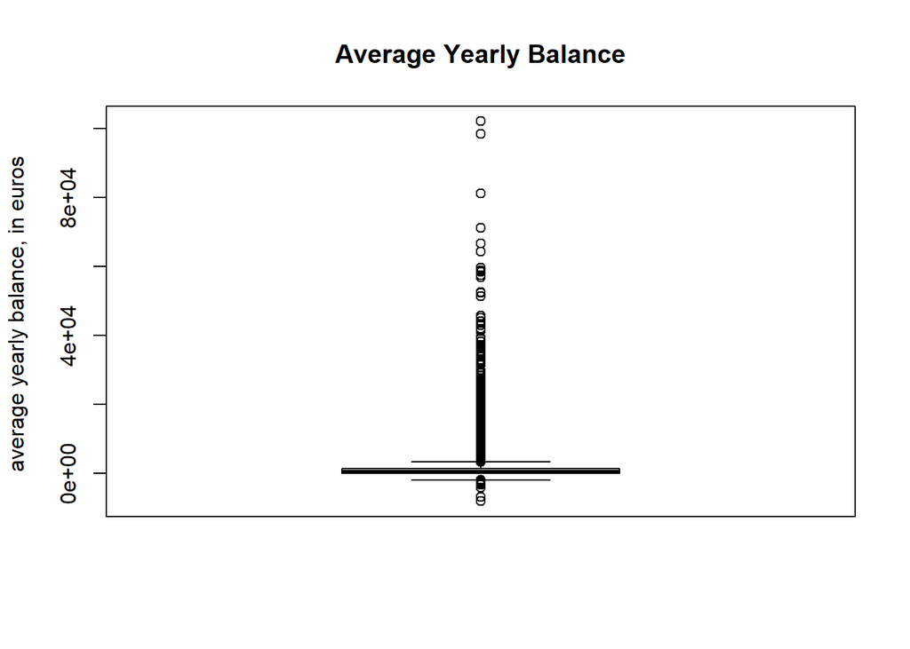

```r
boxplot(train$balance, ylab = "average yearly balance, in euros ", main = 'Average Yearly Balance')
```

We have outliers on the balance column.

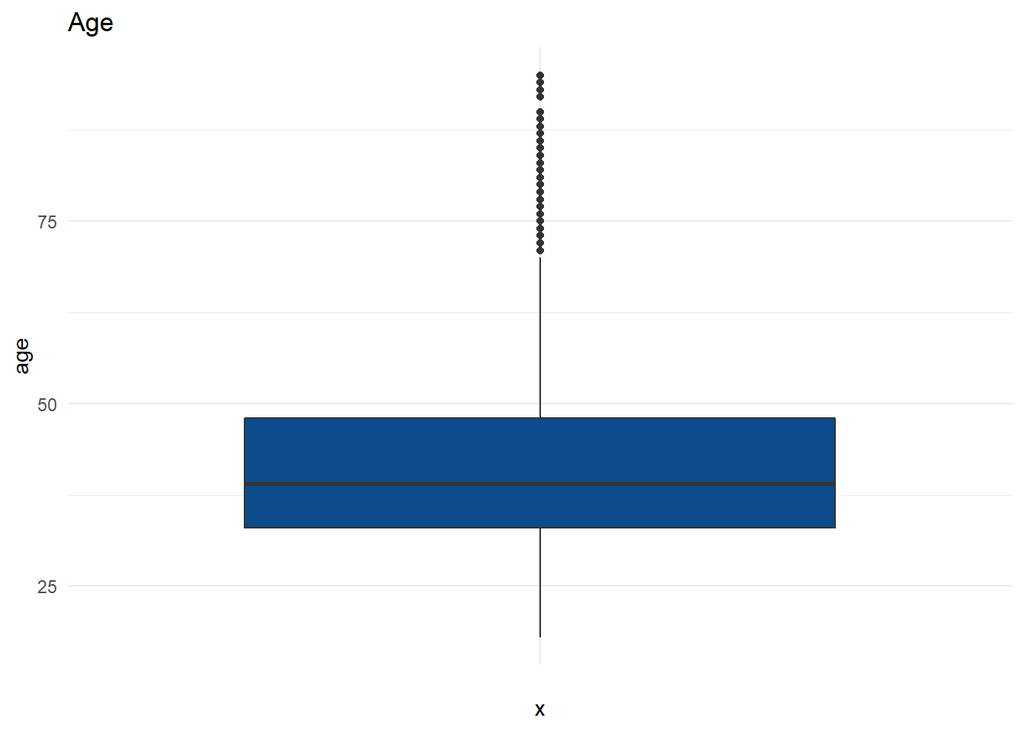

```r
ggplot(train) +
  aes(x = "", y =age) +
  geom_boxplot(fill = "#0c4c8a") +
  theme_minimal() + labs(title = 'Age')
```

We have outlier in age

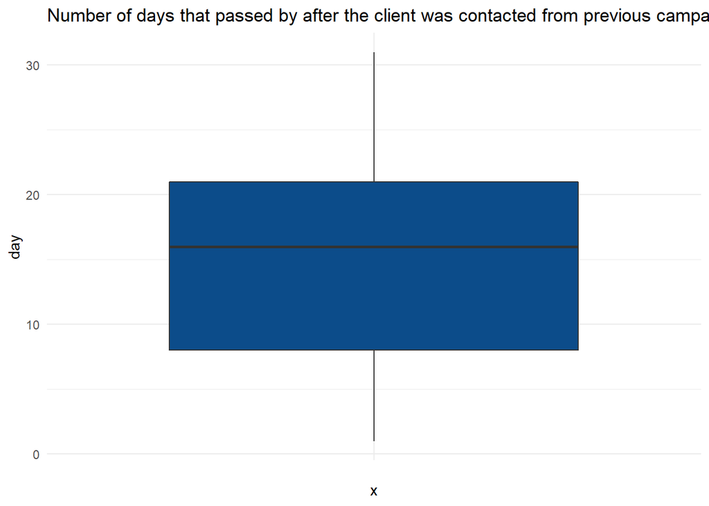

```r
ggplot(train) +
  aes(x = "", y =day) +
  geom_boxplot(fill = "#0c4c8a") +
  theme_minimal() + labs(title = 'Number of days that passed by after the client was contacted from previous campaign')
```

There are no outliers on day column.

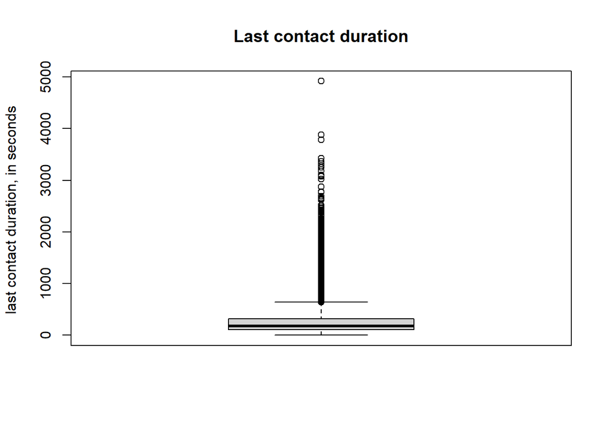

```r
boxplot(train$duration, ylab = "last contact duration, in seconds ", main = 'Last contact duration')
```

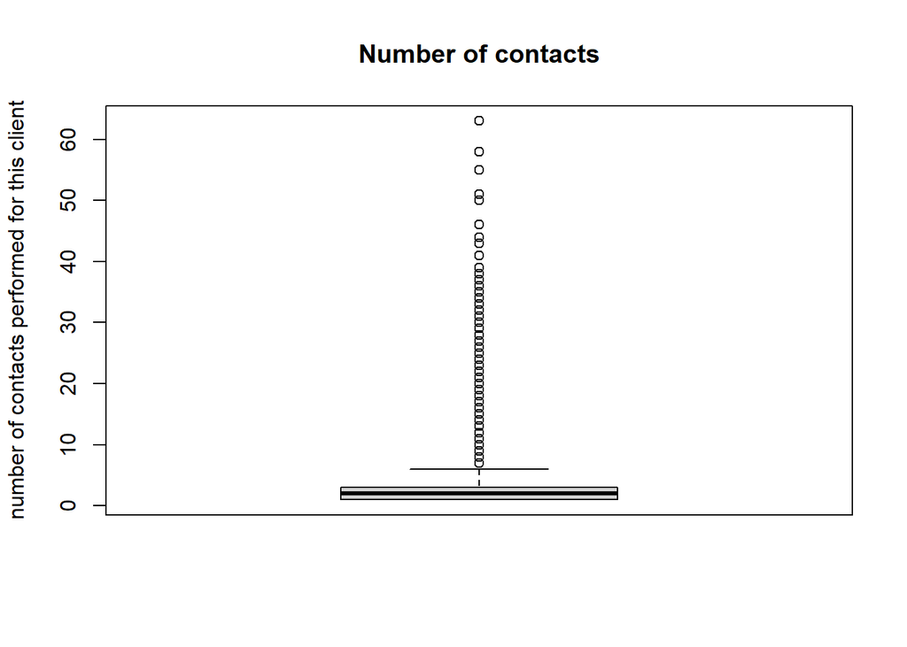

```r
boxplot(train$campaign, ylab = "number of contacts performed for this client", main = 'Number of contacts')
```

Most of the numeric columns have outliers but will not drop them since they are significant for our analysis.

**Test data set**

1. checking for null values

```r
is.null(test)
```

```
## [1] FALSE
```

```r
colSums(is.na(test))
```

```
##       age       job   marital education   default   balance   housing      loan
##         0         0         0         0         0         0         0         0
##   contact       day     month  duration  campaign     pdays  previous  poutcome
##         0         0         0         0         0         0         0         0
##         y
##         0
```

We have no null values

2. checking for duplicates

```r
duplicated_rows <- test[duplicated(test),]
duplicated_rows
```

| age | job | marital | education | default | balance | housing | loan | contact | day | month | duration | campaign | pdays | previous | poutcome | y |
| --- | --- | --- | --- | --- | --- | --- | --- | --- | --- | --- | --- | --- | --- | --- | --- | --- |

We have no duplicates

Will combine the two tables for EDA

```r
df <- rbind(train, test)
head(df)
```

| age | job | marital | education | default | balance | housing | loan | contact | day | month | duration | campaign | pdays | previous | poutcome | y |
| --- | --- | --- | --- | --- | --- | --- | --- | --- | --- | --- | --- | --- | --- | --- | --- | --- |
| 58 | management | married | tertiary | no | 2143 | yes | no | unknown | 5 | may | 261 | 1 | -1 | 0 | unknown | no |
| 44 | technician | single | secondary | no | 29 | yes | no | unknown | 5 | may | 151 | 1 | -1 | 0 | unknown | no |
| 33 | entrepreneur | married | secondary | no | 2 | yes | yes | unknown | 5 | may | 76 | 1 | -1 | 0 | unknown | no |
| 47 | blue-collar | married | unknown | no | 1506 | yes | no | unknown | 5 | may | 92 | 1 | -1 | 0 | unknown | no |
| 33 | unknown | single | unknown | no | 1 | no | no | unknown | 5 | may | 198 | 1 | -1 | 0 | unknown | no |
| 35 | management | married | tertiary | no | 231 | yes | no | unknown | 5 | may | 139 | 1 | -1 | 0 | unknown | no |

# 4 **Exploratory Data Analysis**

## 4.1 **1. Uni-variate Analysis**

**Age distribution of the customers**

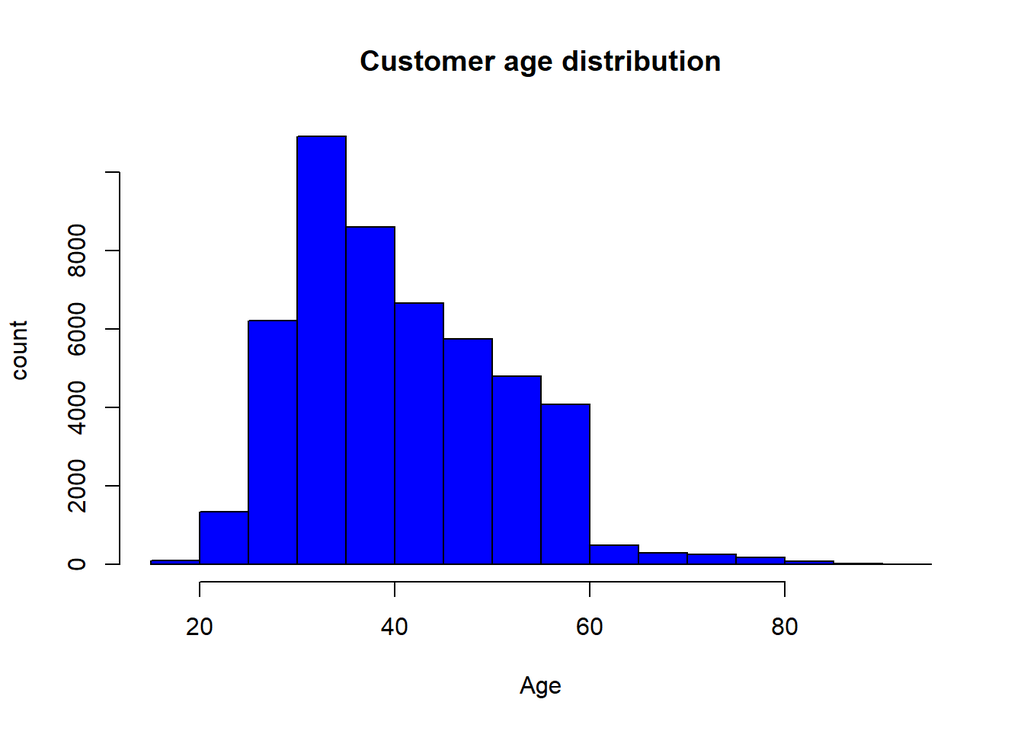

```r
hist((df$age),
main = "Customer age distribution",
     xlab = 'Age',
     ylab = 'count',
     col = "blue")
```

The age bracket of most clients was 35 years, there was an extreme of 95 years and 18 years

**Education level Distribution of the customers**

```r
edu <- (df$education)
edu.frequency <- table(edu)
edu.frequency
```

```
## edu
##   primary secondary  tertiary   unknown
##      7529     25508     14651      2044
```

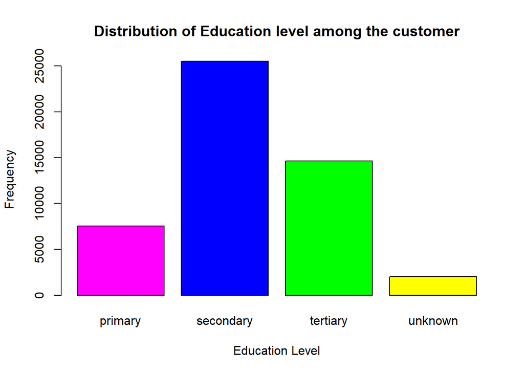

```r
barplot(edu.frequency,
  main="Distribution of Education level among the customer",
  xlab="Education Level",
  ylab = "Frequency",
  col=c("magenta","blue", "green", "yellow"),
  )
```

Most of our customers had a form of education with highest having already reached secondary education followed by tertiary level and the least were those who did not disclose their level of education.

**Job types distribution**

```r
job <- (df$job)
job.frequency <- table(job)
job.frequency
```

```
## job
##        admin.   blue-collar  entrepreneur     housemaid    management
##          5649         10678          1655          1352         10427
##       retired self-employed      services       student    technician
##          2494          1762          4571          1022          8365
##    unemployed       unknown
##          1431           326
```

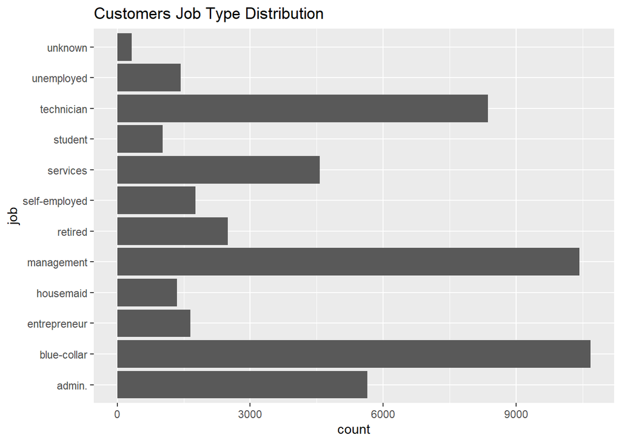

```r
ggplot(df, aes(x=job)) +geom_bar() + ggtitle("Customers Job Type Distribution") + coord_flip()
```

**Marital status**

```r
marital <- (df$marital)
marital.frequency <- table(marital)
marital.frequency
```

```
## marital
## divorced  married   single
##     5735    30011    13986
```

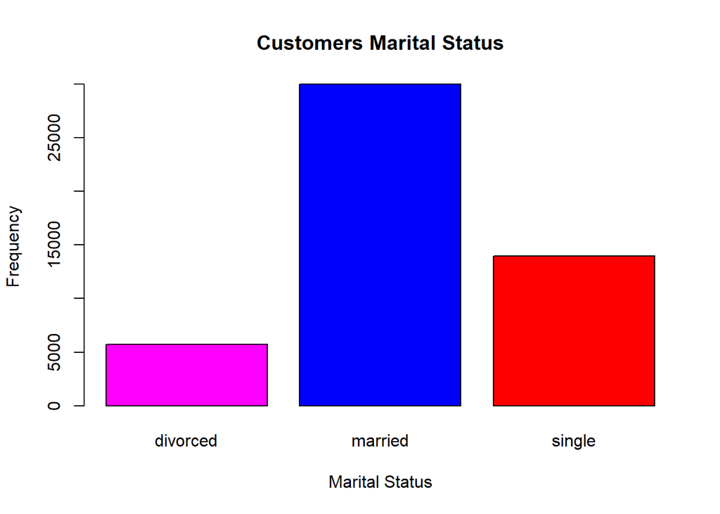

```r
barplot(marital.frequency,
  main="Customers Marital Status",
  xlab="Marital Status",
  ylab = "Frequency",
  col=c("magenta","blue", "red"),
  )
```

Most of the customers participating in the campaigns were married, followed by single people and finally divorced.

**Credit status**

```r
default <- (df$default)
default.frequency <- table(default)
default.frequency
```

```
## default
##    no   yes
## 48841   891
```

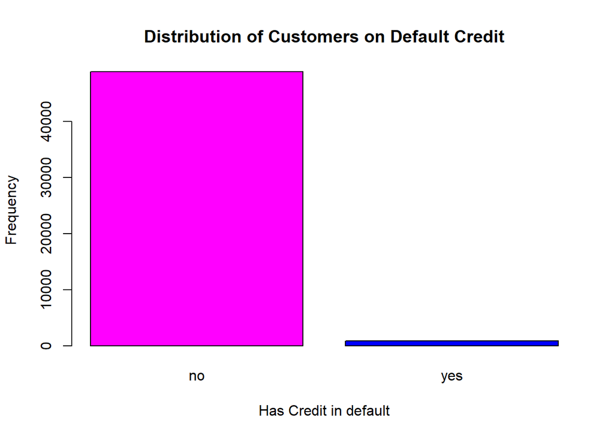

```r
barplot(default.frequency,
  main="Distribution of Customers on Default Credit",
  xlab="Has Credit in default",
  ylab = "Frequency",
  col=c("magenta","blue"),
  )
```

The graph above shows that most customers don’t have credit on default.

**Housing Loan**

```r
housing <- (df$housing)
housing.frequency <- table(housing)
housing.frequency
```

```
## housing
##    no   yes
## 22043 27689
```

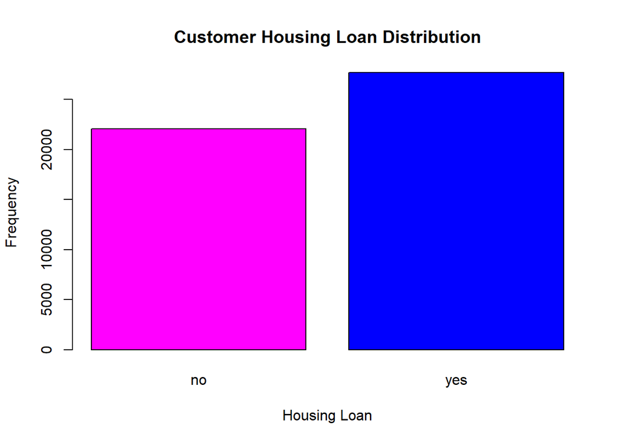

```r
barplot(housing.frequency,
  main="Customer Housing Loan Distribution",
  xlab="Housing Loan",
  ylab = "Frequency",
  col=c("magenta","blue"),
  )
```

Most of the customers have a housing loan.

**Personal loan**

```r
loan <- (df$loan)
loan.frequency <- table(loan)
loan.frequency
```

```
## loan
##    no   yes
## 41797  7935
```

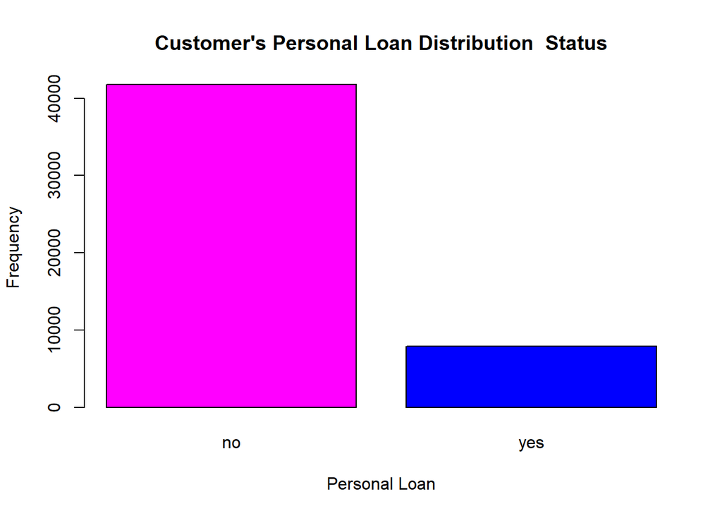

```r
barplot(loan.frequency,
  main="Customer's Personal Loan Distribution  Status",
  xlab="Personal Loan",
  ylab = "Frequency",
  col=c("magenta","blue"),
  )
```

Most customers don’t have a personal loan.

**Outcome of the previous marketing campaign**

```r
outcome <- (df$poutcome)
outcome.frequency <- table(outcome)
outcome.frequency
```

```
## outcome
## failure   other success unknown
##    5391    2037    1640   40664
```

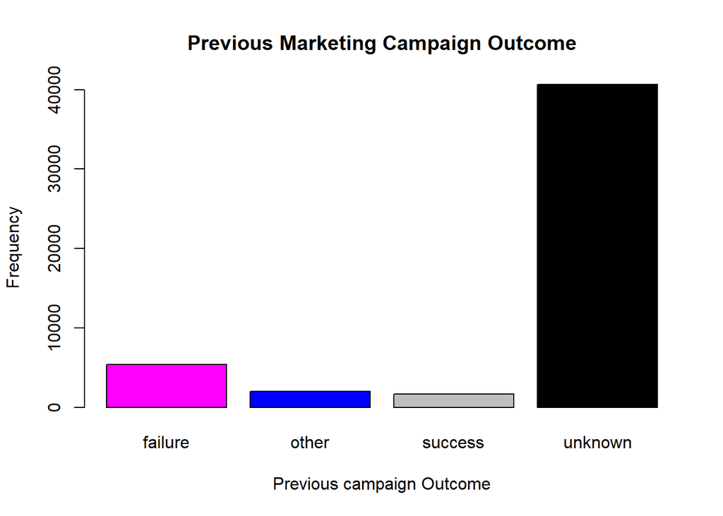

```r
barplot(outcome.frequency,
  main="Previous Marketing Campaign Outcome",
  xlab="Previous campaign Outcome",
  ylab = "Frequency",
  col=c("magenta","blue", "grey", "black"),
  )
```

The graph shows most customers outcome of the previous marketing campaign to be unknown, with the least of the current focus group ending in success

**Subscription to term deposit**

```r
sb <- (df$y)
sb.frequency <- table(sb)
sb.frequency
```

```
## sb
##    no   yes
## 43922  5810
```

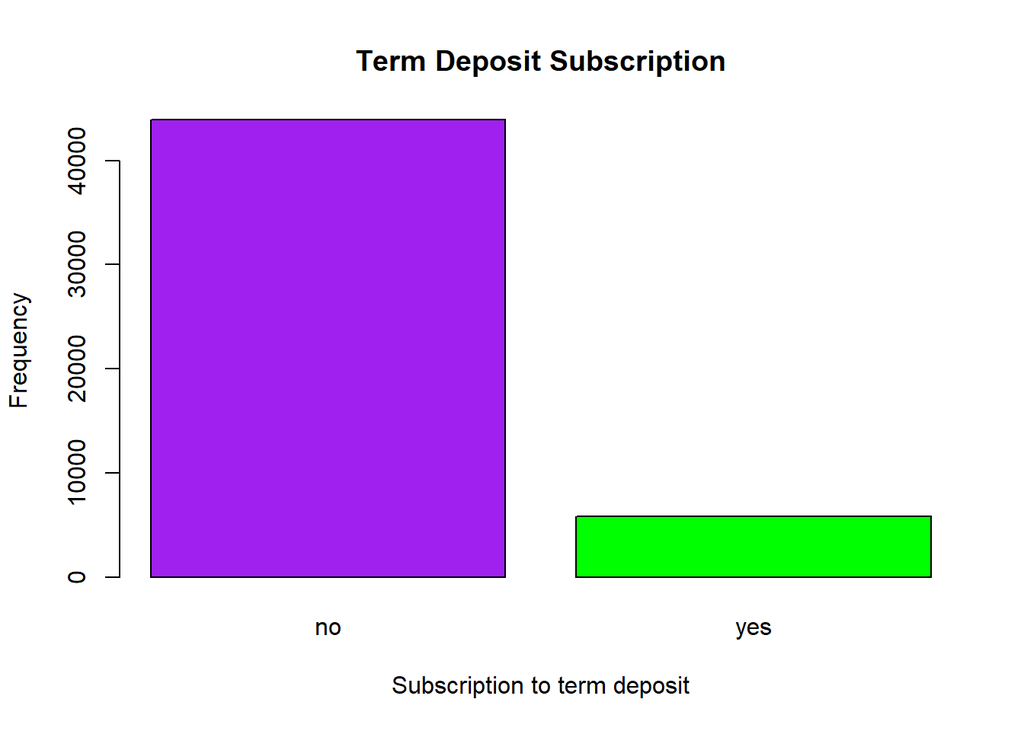

```r
barplot(sb.frequency,
  main="Term Deposit Subscription",
  xlab="Subscription to term deposit",
  ylab = "Frequency",
  col=c("Purple","green"),
  )
```

The graph shows the outcome towards term deposit subscription where most customers did not subscribe.

## 4.2 **2. Bivariate Analysis**

```r
library(reshape2)
```

**Comparing age vs average yearly balance**

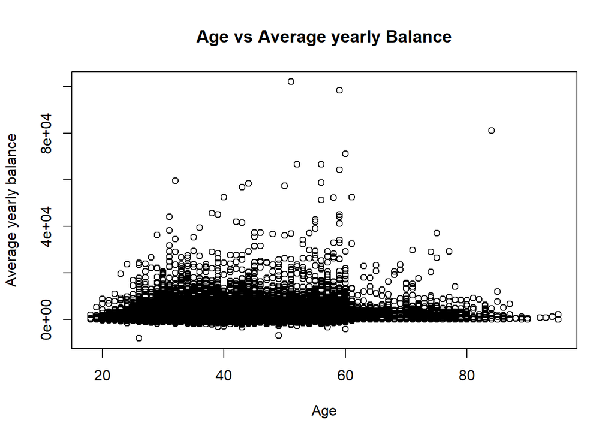

```r
plot((df$age), (df$balance),
     main = "Age vs Average yearly Balance",
     xlab = 'Age',
     ylab = 'Average yearly balance')
```

There is high concentration of average yearly balance of most customers despite age to be on the lower limit, however, around age 40 to 60 years we have outliers on the upper limit.

**Does having a housing loan affect whether a client subscribed to a term deposit or not?**

```r
library(plyr)
```

```r
counts <- ddply(df, .(df$y, df$housing), nrow)
names(counts) <- c("term deposit", "housing loan", "Freq")
counts
```

| term deposit | housing loan | Freq |
| --- | --- | --- |
| no | no | 18388 |
| no | yes | 25534 |
| yes | no | 3655 |
| yes | yes | 2155 |

The table shows that most people with housing loan didn’t no subscribe to a term deposit.

We can see this visually

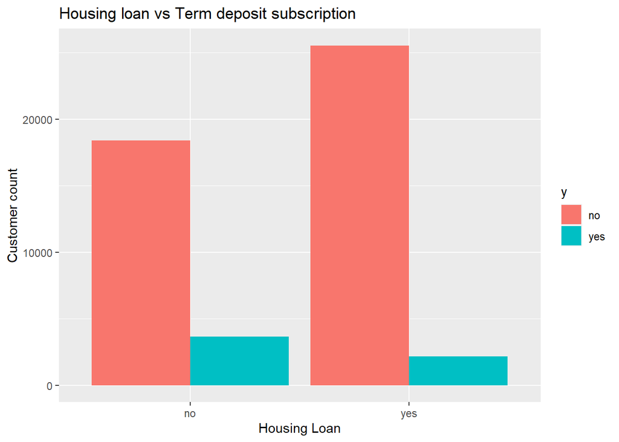

```r
ggplot(df, aes(fill=y, x=housing)) + geom_bar(position = "dodge" ) + labs(title = 'Housing loan vs Term deposit subscription',
    x = 'Housing Loan', y = 'Customer count')
```

We can therefore answer our objective that indeed having a housing loan affects if someone subscribes to a term deposit or not. We can clearly see most of the people who subscribed to a term deposit did not have a housing loan.

**Does having a Personal loan affect whether a client subscribed to a term deposit or not?**

```r
loan_counts <- ddply(df, .(df$y, df$loan), nrow)
names(loan_counts) <- c("Term deposit", "Personal loan", "Freq")
loan_counts
```

| Term deposit | Personal loan | Freq |
| --- | --- | --- |
| no | no | 36514 |
| no | yes | 7408 |
| yes | no | 5283 |
| yes | yes | 527 |

The table shows that most people with personal loan did not subscribe to a term deposit.

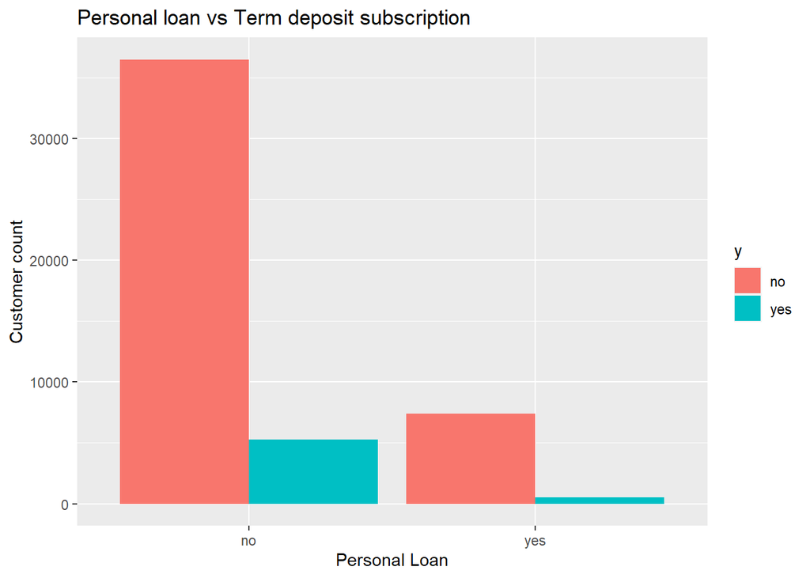

```r
ggplot(df, aes(fill=y, x=loan)) + geom_bar(position = "dodge" ) + labs(title = 'Personal loan vs Term deposit subscription',
    x = 'Personal Loan', y = 'Customer count')
```

We can therefore answer our objective that indeed having a personal loan affects if someone subscribes to a term deposit or not. We can clearly see most of the people who subscribed to a term deposit did not have a personal loan.

**Does previous campaign success lead to current campaign success to term deposit subscription?**

```r
previous_outcome <- ddply(df, .(df$y, df$poutcome), nrow)
names(previous_outcome) <- c("Term deposit", "Previous outcome", "Freq")
previous_outcome
```

| Term deposit | Previous outcome | Freq |
| --- | --- | --- |
| no | failure | 4710 |
| no | other | 1692 |
| no | success | 579 |
| no | unknown | 36941 |
| yes | failure | 681 |
| yes | other | 345 |
| yes | success | 1061 |
| yes | unknown | 3723 |

From this table we can see previous success indeed lead to current success.

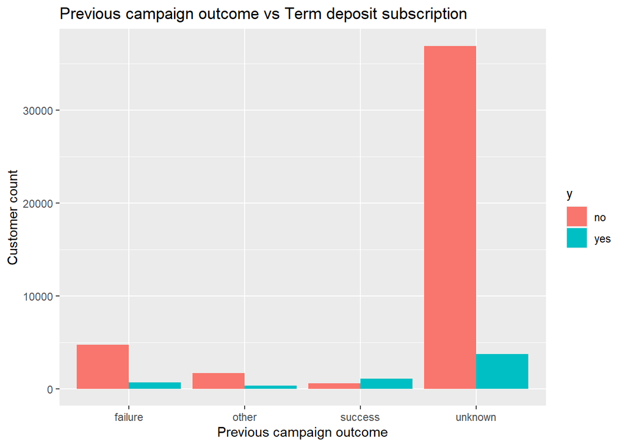

```r
ggplot(df, aes(fill=y, x=poutcome)) + geom_bar(position = "dodge" ) + labs(title = 'Previous campaign outcome vs Term deposit subscription',
    x = 'Previous campaign outcome', y = 'Customer count')
```

The success of previous campaign had a higher chance of success to the current campaign.

**Does having credit on default affect term deposit subscription?**

```r
default_count <- ddply(df, .(df$y, df$default), nrow)
names(default_count) <- c("term deposit", "Credit by Default", "Freq")
default_count
```

| term deposit | Credit by Default | Freq |
| --- | --- | --- |
| no | no | 43092 |
| no | yes | 830 |
| yes | no | 5749 |
| yes | yes | 61 |

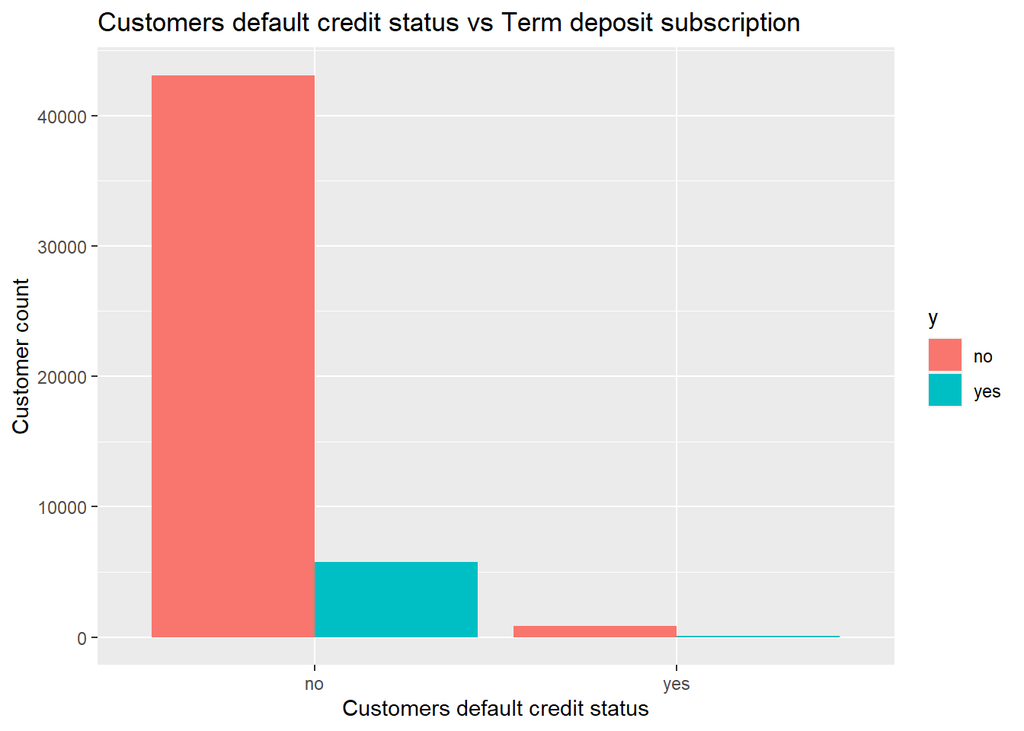

```r
ggplot(df, aes(fill=y, x=default)) + geom_bar(position = "dodge" ) + labs(title = 'Customers default credit status vs Term deposit subscription',
    x = 'Customers default credit status', y = 'Customer count')
```

The graph and table above shows having a credit on default doesn’t lead to term deposit subscription.

**Job type vs Term deposit subscription**

```r
job_count <- ddply(df, .(df$job, df$y), nrow)
names(job_count) <- c("Job type", "term deposit", "Freq")
job_count
```

| Job type | term deposit | Freq |
| --- | --- | --- |
| admin. | no | 4960 |
| admin. | yes | 689 |
| blue-collar | no | 9901 |
| blue-collar | yes | 777 |
| entrepreneur | no | 1517 |
| entrepreneur | yes | 138 |
| housemaid | no | 1229 |
| housemaid | yes | 123 |
| management | no | 8995 |
| management | yes | 1432 |

[output cut: 14 more lines]

The table above shows that most people in management subscribed to a term deposit, followed by blue collar and administrative.

**Marital status vs Term deposit subscription**

```r
maritalstatus <- ddply(df, .(df$marital, df$y), nrow)
names(maritalstatus) <- c("maritalstatus", "Term Deposit", "Freq")
maritalstatus
```

| maritalstatus | Term Deposit | Freq |
| --- | --- | --- |
| divorced | no | 5036 |
| divorced | yes | 699 |
| married | no | 26979 |
| married | yes | 3032 |
| single | no | 11907 |
| single | yes | 2079 |

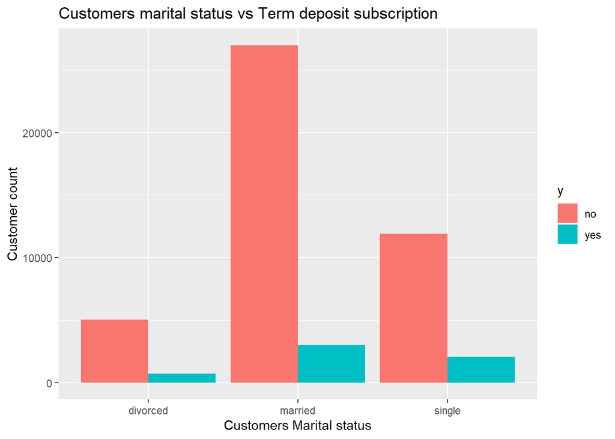

```r
ggplot(df, aes(fill=y, x=marital)) + geom_bar(position = "dodge" ) + labs(title = 'Customers marital status vs Term deposit subscription',
    x = 'Customers Marital status', y = 'Customer count')
```

Most married people subscribed to term deposit, however, they were also the majority in the campaign.

**Education Level vs Term deposit subscription**

```r
edu_count<- ddply(df, .(df$education, df$y), nrow)
names(edu_count) <- c("Education level", "term deposit", "Freq")
edu_count
```

| Education level | term deposit | Freq |
| --- | --- | --- |
| primary | no | 6874 |
| primary | yes | 655 |
| secondary | no | 22813 |
| secondary | yes | 2695 |
| tertiary | no | 12462 |
| tertiary | yes | 2189 |
| unknown | no | 1773 |
| unknown | yes | 271 |

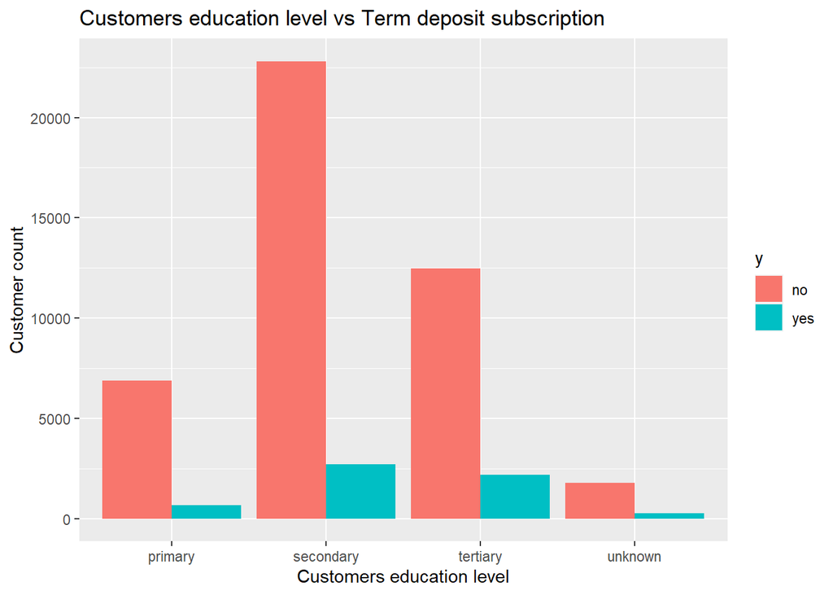

```r
ggplot(df, aes(fill=y, x=education)) + geom_bar(position = "dodge" ) +labs(title = 'Customers education level vs Term deposit subscription',
    x = 'Customers education level', y = 'Customer count')
```

The graph above shows most customers as previously observed had some level of secondary education. However, proportionally most tertiary educational holder actually subscribed to term deposit compared to other levels of education.

**Multiple calls(campaign) contact led to a term deposit or not?**

```r
campaign_count<- ddply(df, .(df$campaign, df$y), nrow)
names(campaign_count) <- c("Campaign", "term deposit", "Freq")
campaign_count
```

| Campaign | term deposit | Freq |
| --- | --- | --- |
| 1 | no | 16477 |
| 1 | yes | 2801 |
| 2 | no | 12230 |
| 2 | yes | 1539 |
| 3 | no | 5404 |
| 3 | yes | 675 |
| 4 | no | 3487 |
| 4 | yes | 360 |
| 5 | no | 1783 |
| 5 | yes | 148 |

[output cut: 60 more lines]

The table above shows that multiple contact during the campaign did not result to subscription. Most the people who actually subscribed to term deposit were only contacted once.

## 4.3 **3. Multivariate Analysis**

Getting a summary of the variables

```r
summary(df)
```

```
##       age            job              marital           education
##  Min.   :18.00   Length:49732       Length:49732       Length:49732
##  1st Qu.:33.00   Class :character   Class :character   Class :character
##  Median :39.00   Mode  :character   Mode  :character   Mode  :character
##  Mean   :40.96
##  3rd Qu.:48.00
##  Max.   :95.00
##    default             balance         housing              loan
##  Length:49732       Min.   : -8019   Length:49732       Length:49732
##  Class :character   1st Qu.:    72   Class :character   Class :character
##  Mode  :character   Median :   448   Mode  :character   Mode  :character
##                     Mean   :  1368
##                     3rd Qu.:  1431
##                     Max.   :102127
##    contact               day           month              duration
##  Length:49732       Min.   : 1.00   Length:49732       Min.   :   0.0
##  Class :character   1st Qu.: 8.00   Class :character   1st Qu.: 103.0
##  Mode  :character   Median :16.00   Mode  :character   Median : 180.0
##                     Mean   :15.82                      Mean   : 258.7
##                     3rd Qu.:21.00                      3rd Qu.: 320.0
##                     Max.   :31.00                      Max.   :4918.0
##     campaign          pdays           previous          poutcome
##  Min.   : 1.000   Min.   : -1.00   Min.   :  0.0000   Length:49732
##  1st Qu.: 1.000   1st Qu.: -1.00   1st Qu.:  0.0000   Class :character
##  Median : 2.000   Median : -1.00   Median :  0.0000   Mode  :character
##  Mean   : 2.767   Mean   : 40.16   Mean   :  0.5769
##  3rd Qu.: 3.000   3rd Qu.: -1.00   3rd Qu.:  0.0000
##  Max.   :63.000   Max.   :871.00   Max.   :275.0000
##       y
##  Length:49732
##  Class :character
##  Mode  :character
##
##
##
```

The summary above shows the following:

[output not shown]

**Checking for correlation**

```r
library(corrplot)
```

```r
numeric <- df %>%
  select_if(is.numeric) %>%
  select("age", "balance", "duration", "day", "campaign", "pdays", "previous")
```

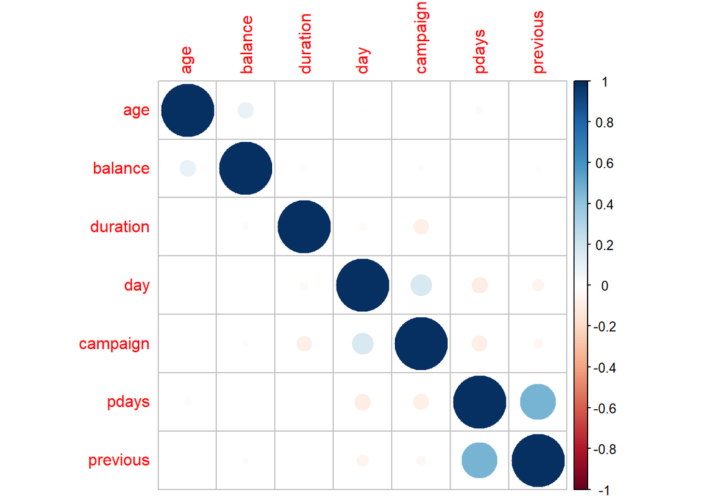

```r
corrplot(cor(numeric))
```

# 5 **Modeling**

Will be performing our modeling using supervised method then challenge with unsupervised learning.

Loading important libraries

```r
library(caTools)
library(party)
library(dplyr)
library(magrittr)
library(randomForest)
library(e1071)
library(caTools)
library(class)
library(rpart)
library(rpart.plot)
library(caret)
library(caretEnsemble)
library(psych)
library(Amelia)
library(mice)
library(GGally)
```

## 5.1 **A. Pre-processing**

Previewing our train data set.

```r
head(df)
```

| age | job | marital | education | default | balance | housing | loan | contact | day | month | duration | campaign | pdays | previous | poutcome | y |
| --- | --- | --- | --- | --- | --- | --- | --- | --- | --- | --- | --- | --- | --- | --- | --- | --- |
| 58 | management | married | tertiary | no | 2143 | yes | no | unknown | 5 | may | 261 | 1 | -1 | 0 | unknown | no |
| 44 | technician | single | secondary | no | 29 | yes | no | unknown | 5 | may | 151 | 1 | -1 | 0 | unknown | no |
| 33 | entrepreneur | married | secondary | no | 2 | yes | yes | unknown | 5 | may | 76 | 1 | -1 | 0 | unknown | no |
| 47 | blue-collar | married | unknown | no | 1506 | yes | no | unknown | 5 | may | 92 | 1 | -1 | 0 | unknown | no |
| 33 | unknown | single | unknown | no | 1 | no | no | unknown | 5 | may | 198 | 1 | -1 | 0 | unknown | no |
| 35 | management | married | tertiary | no | 231 | yes | no | unknown | 5 | may | 139 | 1 | -1 | 0 | unknown | no |

Selecting numeric columns

```r
num <- df[, c(1,6,10,12:15)]
head(num)
```

| age | balance | day | duration | campaign | pdays | previous |
| --- | --- | --- | --- | --- | --- | --- |
| 58 | 2143 | 5 | 261 | 1 | -1 | 0 |
| 44 | 29 | 5 | 151 | 1 | -1 | 0 |
| 33 | 2 | 5 | 76 | 1 | -1 | 0 |
| 47 | 1506 | 5 | 92 | 1 | -1 | 0 |
| 33 | 1 | 5 | 198 | 1 | -1 | 0 |
| 35 | 231 | 5 | 139 | 1 | -1 | 0 |

Selecting categorical columns

```r
cat <- df[, c(2:5,7:9,11,16,17)]
head(cat)
```

| job | marital | education | default | housing | loan | contact | month | poutcome | y |
| --- | --- | --- | --- | --- | --- | --- | --- | --- | --- |
| management | married | tertiary | no | yes | no | unknown | may | unknown | no |
| technician | single | secondary | no | yes | no | unknown | may | unknown | no |
| entrepreneur | married | secondary | no | yes | yes | unknown | may | unknown | no |
| blue-collar | married | unknown | no | yes | no | unknown | may | unknown | no |
| unknown | single | unknown | no | no | no | unknown | may | unknown | no |
| management | married | tertiary | no | yes | no | unknown | may | unknown | no |

Label encoding our categorical columns

```r
library(superml)
```

```r
label <- LabelEncoder$new()
cat$job <- label$fit_transform(cat$job)
cat$marital <- label$fit_transform(cat$marital)
cat$education <- label$fit_transform(cat$education)
cat$default <- label$fit_transform(cat$default)
cat$housing <- label$fit_transform(cat$housing)
cat$loan <- label$fit_transform(cat$loan)
cat$contact <- label$fit_transform(cat$contact)
cat$month <- label$fit_transform(cat$month)
cat$poutcome <- label$fit_transform(cat$poutcome)
cat$y <- label$fit_transform(cat$y)
head(cat)
```

| job | marital | education | default | housing | loan | contact | month | poutcome | y |
| --- | --- | --- | --- | --- | --- | --- | --- | --- | --- |
| 0 | 0 | 0 | 0 | 0 | 0 | 0 | 0 | 0 | 0 |
| 1 | 1 | 1 | 0 | 0 | 0 | 0 | 0 | 0 | 0 |
| 2 | 0 | 1 | 0 | 0 | 1 | 0 | 0 | 0 | 0 |
| 3 | 0 | 2 | 0 | 0 | 0 | 0 | 0 | 0 | 0 |
| 4 | 1 | 2 | 0 | 1 | 0 | 0 | 0 | 0 | 0 |
| 0 | 0 | 0 | 0 | 0 | 0 | 0 | 0 | 0 | 0 |

joining now categorical and numeric data

```r
data <-cbind(num, cat)
head(data)
```

|  | age | balance | day | duration | campaign | pdays | previous | job | marital | education | default | housing | loan | contact | month | poutcome | y |
| --- | --- | --- | --- | --- | --- | --- | --- | --- | --- | --- | --- | --- | --- | --- | --- | --- | --- |
| 1 | 58 | 2143 | 5 | 261 | 1 | -1 | 0 | 0 | 0 | 0 | 0 | 0 | 0 | 0 | 0 | 0 | 0 |
| 2 | 44 | 29 | 5 | 151 | 1 | -1 | 0 | 1 | 1 | 1 | 0 | 0 | 0 | 0 | 0 | 0 | 0 |
| 3 | 33 | 2 | 5 | 76 | 1 | -1 | 0 | 2 | 0 | 1 | 0 | 0 | 1 | 0 | 0 | 0 | 0 |
| 4 | 47 | 1506 | 5 | 92 | 1 | -1 | 0 | 3 | 0 | 2 | 0 | 0 | 0 | 0 | 0 | 0 | 0 |
| 5 | 33 | 1 | 5 | 198 | 1 | -1 | 0 | 4 | 1 | 2 | 0 | 1 | 0 | 0 | 0 | 0 | 0 |
| 6 | 35 | 231 | 5 | 139 | 1 | -1 | 0 | 0 | 0 | 0 | 0 | 0 | 0 | 0 | 0 | 0 | 0 |

## 5.2 **B. Feature selection**

Will also perform feature selection to remove redundant feature in our data set.

1. Getting a correlation Matrix

```r
correlationMatrix <- cor(data)
```

2. Choosing the highly correlated features

```r
highlyCorrelated <- findCorrelation(correlationMatrix, cutoff=0.70)
```

3. Removing the redundant (highly correlated) features

```r
Dataset2<-data[-highlyCorrelated]
```

4. Previews the correlation matrix

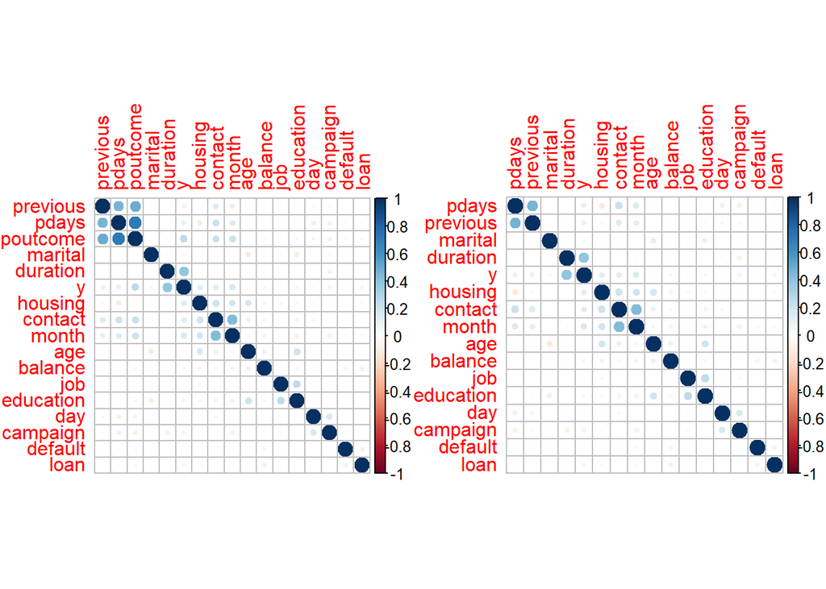

```r
par(mfrow = c(1, 2))
corrplot(correlationMatrix, order = "hclust")
corrplot(cor(Dataset2), order = "hclust")
```

## 5.3 **C. Dealing with class Imbalance**

Previewing our classes

```r
head(data)
```

|  | age | balance | day | duration | campaign | pdays | previous | job | marital | education | default | housing | loan | contact | month | poutcome | y |
| --- | --- | --- | --- | --- | --- | --- | --- | --- | --- | --- | --- | --- | --- | --- | --- | --- | --- |
| 1 | 58 | 2143 | 5 | 261 | 1 | -1 | 0 | 0 | 0 | 0 | 0 | 0 | 0 | 0 | 0 | 0 | 0 |
| 2 | 44 | 29 | 5 | 151 | 1 | -1 | 0 | 1 | 1 | 1 | 0 | 0 | 0 | 0 | 0 | 0 | 0 |
| 3 | 33 | 2 | 5 | 76 | 1 | -1 | 0 | 2 | 0 | 1 | 0 | 0 | 1 | 0 | 0 | 0 | 0 |
| 4 | 47 | 1506 | 5 | 92 | 1 | -1 | 0 | 3 | 0 | 2 | 0 | 0 | 0 | 0 | 0 | 0 | 0 |
| 5 | 33 | 1 | 5 | 198 | 1 | -1 | 0 | 4 | 1 | 2 | 0 | 1 | 0 | 0 | 0 | 0 | 0 |
| 6 | 35 | 231 | 5 | 139 | 1 | -1 | 0 | 0 | 0 | 0 | 0 | 0 | 0 | 0 | 0 | 0 | 0 |

```r
class<- (data$y)
class.frequency <- table(class)
class.frequency
```

```
## class
##     0     1
## 43922  5810
```

From this frequency table we have a huge class imbalance and will deal with them before moving forward.

```r
library(imbalance)
```

Selecting the two class in the data set

```r
df_p <- which(data$y == "0")
df_n <- which(data$y == "1")
```

**Under sampling the majority class.**

```r
nsample <- 5810
pick_negative <- sample(df_p, nsample)

undersample_df1 <- data[c(df_n, pick_negative), ]

dim(undersample_df1)
```

```
## [1] 11620    17
```

The final product we have a new data set with 11620 rows and 17 columns

Previewing our response variable class

```r
table(undersample_df1$y)
```

```
##
##    0    1
## 5810 5810
```

Now will go ahead and split our data into train and test data set

```r
train.size = floor(0.75*nrow(undersample_df1))
train.index = sample(1:nrow(undersample_df1), train.size)
train.set = undersample_df1[train.index,]
test.set = undersample_df1[-train.index,]
x.train = train.set[,-17]
x.test = test.set[,-17]
y.train = train.set[,17]
y.test = test.set[,17]
```

## 5.4 **KNN Classifier Model**

Fitting KNN model

```r
knn.3 <- knn(train = x.train, test = x.test, cl = y.train , k = 5)
```

```r
def = table(predicted = knn.3, true = y.test)
def
```

```
##          true
## predicted    0    1
##         0 1121  338
##         1  353 1093
```

```r
confusionMatrix(def)
```

```
## Confusion Matrix and Statistics
##
##          true
## predicted    0    1
##         0 1121  338
##         1  353 1093
##
##                Accuracy : 0.7621
##                  95% CI : (0.7462, 0.7775)
##     No Information Rate : 0.5074
##     P-Value [Acc > NIR] : <2e-16
##
##                   Kappa : 0.5242
##
##  Mcnemar's Test P-Value : 0.5943
##
##             Sensitivity : 0.7605
##             Specificity : 0.7638
##          Pos Pred Value : 0.7683
##          Neg Pred Value : 0.7559
##              Prevalence : 0.5074
##          Detection Rate : 0.3859
##    Detection Prevalence : 0.5022
##       Balanced Accuracy : 0.7622
##
##        'Positive' Class : 0
##
```

**Parameter tuning**

creating Standardization function

```r
standardize = function(x){
  z <- (x - mean(x)) / sd(x)
  return( z)
}
```

applying the function to the data set

```r
undersample_df2 <-
  apply(undersample_df1, 2, standardize)
head(undersample_df2)
```

```
##             age    balance       day  duration   campaign      pdays   previous
## 84   1.48497332  0.2439696 -1.259277 1.8747220 -0.5374291 -0.4841538 -0.3742031
## 87   1.23327436 -0.4747472 -1.259277 3.0799292 -0.5374291 -0.4841538 -0.3742031
## 88  -0.02522044 -0.0916192 -1.259277 2.8587382 -0.5374291 -0.4841538 -0.3742031
## 130  1.14937471  0.2855664 -1.259277 0.5617552 -0.5374291 -0.4841538 -0.3742031
## 169  1.06547506 -0.4312739 -1.259277 0.8283186 -0.1884531 -0.4841538 -0.3742031
## 271  0.05867922 -0.4888213 -1.259277 0.5135469 -0.1884531 -0.4841538 -0.3742031
##            job    marital   education    default    housing      loan   contact
## 84   0.7357723 -0.7841811  0.02026809 -0.1271889 -1.0484622 -0.389973 -1.705916
## 87   0.7357723 -0.7841811  0.02026809 -0.1271889  0.9536957 -0.389973 -1.705916
## 88  -0.8076016 -0.7841811  0.02026809 -0.1271889 -1.0484622 -0.389973 -1.705916
## 130  1.0444471 -0.7841811  0.02026809 -0.1271889 -1.0484622 -0.389973 -1.705916
## 169  0.7357723 -0.7841811 -1.02646594 -0.1271889  0.9536957 -0.389973 -1.705916
## 271 -1.1162764  0.6596763 -1.02646594 -0.1271889 -1.0484622  2.564060 -1.705916
##         month   poutcome        y
## 84  -1.032287 -0.5178625 0.999957
## 87  -1.032287 -0.5178625 0.999957
## 88  -1.032287 -0.5178625 0.999957
## 130 -1.032287 -0.5178625 0.999957
## 169 -1.032287 -0.5178625 0.999957
## 271 -1.032287 -0.5178625 0.999957
```

```r
train1.size = floor(0.75*nrow(undersample_df2))
train1.index = sample(1:nrow(undersample_df1), train1.size)
train1.set = undersample_df2[train1.index,]
test1.set = undersample_df2[-train1.index,]
x.train1 = train1.set[,-17]
x.test1 = test1.set[,-17]
y.train1 = train1.set[,17]
y.test1 = test1.set[,17]
```

```r
knn5 <- knn(train = x.train1, test = x.test1, cl = y.train1 , k = 5)
```

```r
defp = table(predicted = knn5, true = y.test1)
```

```r
confusionMatrix(defp)
```

```
## Confusion Matrix and Statistics
##
##                     true
## predicted            -0.999956969814305 0.999956969814305
##   -0.999956969814305               1214               331
##   0.999956969814305                 271              1089
##
##                Accuracy : 0.7928
##                  95% CI : (0.7776, 0.8074)
##     No Information Rate : 0.5112
##     P-Value [Acc > NIR] : < 2e-16
##
##                   Kappa : 0.585
##
##  Mcnemar's Test P-Value : 0.01619
##
##             Sensitivity : 0.8175
##             Specificity : 0.7669
##          Pos Pred Value : 0.7858
##          Neg Pred Value : 0.8007
##              Prevalence : 0.5112
##          Detection Rate : 0.4179
##    Detection Prevalence : 0.5318
##       Balanced Accuracy : 0.7922
##
##        'Positive' Class : -0.999956969814305
##
```

## 5.5 **Naive Bayes**

Fitting Naive Bayes Model

```r
set.seed(120)
classifier_cl <- naiveBayes(y.train ~ ., data = x.train)
```

Predicting on test data’

```r
y_pred <- predict(classifier_cl, newdata = x.test)
```

Confusion Matrix

```r
cm <- table(y.test, y_pred)
cm
```

```
##       y_pred
## y.test    0    1
##      0 1133  341
##      1  334 1097
```

Model Evaluation

```r
confusionMatrix(cm)
```

```
## Confusion Matrix and Statistics
##
##       y_pred
## y.test    0    1
##      0 1133  341
##      1  334 1097
##
##                Accuracy : 0.7676
##                  95% CI : (0.7518, 0.7829)
##     No Information Rate : 0.505
##     P-Value [Acc > NIR] : <2e-16
##
##                   Kappa : 0.5352
##
##  Mcnemar's Test P-Value : 0.8174
##
##             Sensitivity : 0.7723
##             Specificity : 0.7629
##          Pos Pred Value : 0.7687
##          Neg Pred Value : 0.7666
##              Prevalence : 0.5050
##          Detection Rate : 0.3900
##    Detection Prevalence : 0.5074
##       Balanced Accuracy : 0.7676
##
##        'Positive' Class : 0
##
```

## 5.6 **SVM**

Fitting SVM to the Training set

```r
classifier = svm(formula = y.train ~ .,
                 data = x.train,
                 type = 'C-classification',
                 kernel = 'linear')
```

Predicting the Test set results

```r
y_pred = predict(classifier, newdata = x.test)
```

Making the Confusion Matrix

```r
cm = table(y.test, y_pred)
cm
```

```
##       y_pred
## y.test    0    1
##      0 1215  259
##      1  255 1176
```

```r
confusionMatrix(cm)
```

```
## Confusion Matrix and Statistics
##
##       y_pred
## y.test    0    1
##      0 1215  259
##      1  255 1176
##
##                Accuracy : 0.8231
##                  95% CI : (0.8087, 0.8368)
##     No Information Rate : 0.506
##     P-Value [Acc > NIR] : <2e-16
##
##                   Kappa : 0.6461
##
##  Mcnemar's Test P-Value : 0.8947
##
##             Sensitivity : 0.8265
##             Specificity : 0.8195
##          Pos Pred Value : 0.8243
##          Neg Pred Value : 0.8218
##              Prevalence : 0.5060
##          Detection Rate : 0.4182
##    Detection Prevalence : 0.5074
##       Balanced Accuracy : 0.8230
##
##        'Positive' Class : 0
##
```

## 5.7 **Unsupervised Learning using K-Mean Clustering Method**

```r
head(undersample_df1)
```

|  | age | balance | day | duration | campaign | pdays | previous | job | marital | education | default | housing | loan | contact | month | poutcome | y |
| --- | --- | --- | --- | --- | --- | --- | --- | --- | --- | --- | --- | --- | --- | --- | --- | --- | --- |
| 84 | 59 | 2343 | 5 | 1042 | 1 | -1 | 0 | 6 | 0 | 1 | 0 | 0 | 0 | 0 | 0 | 0 | 1 |
| 87 | 56 | 45 | 5 | 1467 | 1 | -1 | 0 | 6 | 0 | 1 | 0 | 1 | 0 | 0 | 0 | 0 | 1 |
| 88 | 41 | 1270 | 5 | 1389 | 1 | -1 | 0 | 1 | 0 | 1 | 0 | 0 | 0 | 0 | 0 | 0 | 1 |
| 130 | 55 | 2476 | 5 | 579 | 1 | -1 | 0 | 7 | 0 | 1 | 0 | 0 | 0 | 0 | 0 | 0 | 1 |
| 169 | 54 | 184 | 5 | 673 | 2 | -1 | 0 | 6 | 0 | 0 | 0 | 1 | 0 | 0 | 0 | 0 | 1 |
| 271 | 42 | 0 | 5 | 562 | 2 | -1 | 0 | 0 | 1 | 0 | 0 | 0 | 1 | 0 | 0 | 0 | 1 |

Selecting the predictor columns

```r
predictorcol <- undersample_df1[, -17]

label <- undersample_df1[, 17]
```

Fitting the K-mean Clustering model using k=2

```r
kmeans.re <- kmeans(predictorcol, centers = 2, nstart = 20)
```

Confusion Matrix

```r
kmeancm <- table(label, kmeans.re$cluster)
kmeancm
```

```
##
## label    1    2
##     0 5589  221
##     1 5511  299
```

The table shows despite being to make correct prediction of the two classes , there was also a case of high mis-prediction for both classes making this model unsuitable

# 6 **Conclusion**

## 6.1 **Recommendation**

For effectiveness of the campaigns the marketing team would:

- Don’t call one customer multiple times (more than 2 times) instead spread that time to other customers.
- Be aware people with previous loan (any form) might not be willing to subscribe to a term deposit.
- Focusing on customers who without credit default is wise since they will be likely to subscribe to term deposit.